# Reproducible Research: Peer Graded Assignment 1

Talha Naushad

February 20, 2019

## Introduction

This R Markdown document has been created for COursera’s “Reproducible Research” course for the first Peer Graded Assignment

The data is based on a personal montoring device from an anonymous individual collected over a 2 month time period. Following is the description of the data that has been provided:

The variables included in this dataset are:

1. steps: Number of steps taking in a 5-minute interval (missing values are coded as NA)
2. date: The date on which the measurement was taken in YYYY-MM-DD format
3. interval: Identifier for the 5-minute interval in which measurement was taken

Using the data this R Markdown file shows the steps taken in completing the analysis as requested by the assignment

## Loading and preprocessing the data

- Data is loaded using the working directory where data is saved.
- Removal of NAs from the steps column is done
- Summary of the data is obtained

```r
setwd("C:/Users/talha/Downloads/5-Reproducible Research/Week2/repdata_data_activity")
df<-read.csv("activity.csv", colClasses = c("numeric","Date","numeric"))
df2<-df[!(is.na(df$steps)),]
head(df2)
```

```
##     steps       date interval
## 289     0 2012-10-02        0
## 290     0 2012-10-02        5
## 291     0 2012-10-02       10
## 292     0 2012-10-02       15
## 293     0 2012-10-02       20
## 294     0 2012-10-02       25
```

```r
str(df2)
```

```
## 'data.frame':    15264 obs. of  3 variables:
##  $ steps   : num  0 0 0 0 0 0 0 0 0 0 ...
##  $ date    : Date, format: "2012-10-02" "2012-10-02" ...
##  $ interval: num  0 5 10 15 20 25 30 35 40 45 ...
```

## What is mean total number of steps taken per day?

## Assignment Questions - Section 1

**Q1 Calculate the total number of steps taken per day**

```r
sum_steps<-aggregate(steps~date,df2,sum)
head(sum_steps)
```

```
##         date steps
## 1 2012-10-02   126
## 2 2012-10-03 11352
## 3 2012-10-04 12116
## 4 2012-10-05 13294
## 5 2012-10-06 15420
## 6 2012-10-07 11015
```

**Q2 Make a histogram of the total number of steps taken each day**

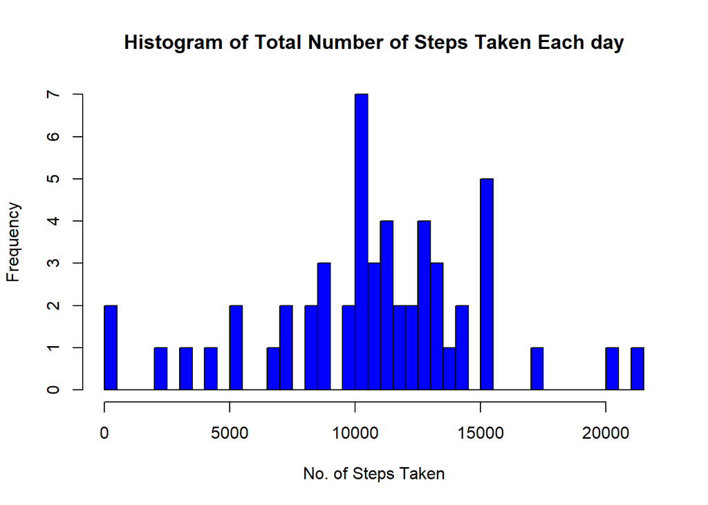

```r
hist(sum_steps$steps, col = "blue", xlab = "No. of Steps Taken", main = "Histogram of Total Number of Steps Taken Each day", breaks = 40)
```

**Q3 Calculate and report the mean and median of the total number of steps taken per day**

```r
steps_mean<-mean(sum_steps$steps)
steps_median<-median(sum_steps$steps)
```

Mean value calculated is *10766.19*, and the Median value *10765*

## What is the average daily activity pattern?

## Assignment Questions - Section 2

**Q1 Make a time series plot (i.e. type=“1”) of the 5-minute interval (x-axis) and the average number of steps taken, averaged across all days (y-axis)**

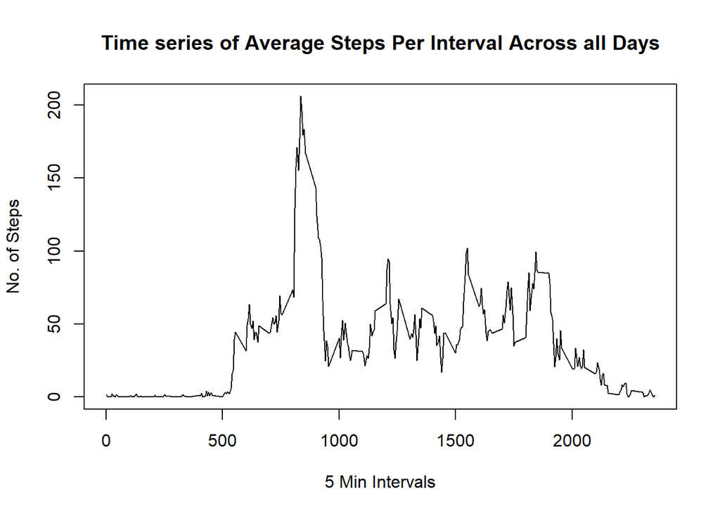

```r
avg_daily_pattern<-aggregate(steps~interval,df2,mean)
plot(x=avg_daily_pattern$interval,y=avg_daily_pattern$steps, type = "l",main = "Time series of Average Steps Per Interval Across all Days", ylab = "No. of Steps", xlab = "5 Min Intervals")
```

**Q2 Which 5-minute interval, on average across all the days in the dataset, contains the maximum number of steps?**

The 5 minute interval which has the maximum number of steps across all intervals is *835*

## Assignment Questions - Section 3

**Q1 Calculate and report the total number of missing values in the dataset (i.e. the total number of rows with NAs)**

The total number of NAs across all 3 columns in the data set are calculated below:

```r
sum(is.na(df$steps))+ sum(is.na(df$interval))+ sum(is.na(df$date))
```

```
## [1] 2304
```

Therefore we can see that 2304 rows have NAs, all of them in the Steps Variable

**Q2 Devise a strategy for filling in all of the missing values in the dataset**

To impute the mean I use the mean of the 5 minute interval for the corresponding NA value to create a new dataframe called r

**Q3 Create a new dataset that is equal to the original dataset but with the missing data filled in.**

- To achieve this I create a copy of the orginial data set called df3
- I then merge df3 with the average daily pattern dataset conditioned on the intervals. This data set is called r
- I then use a conditional statement where if a NA value is detected in steps the average from the corresponding interval value is replaced

```r
df3<-df
r = merge(df3, avg_daily_pattern, by="interval", suffixes=c(".df3", ".avg_daily_pattern"))
r$steps = ifelse(is.na(r$steps.df3), r$steps.avg_daily_pattern, r$steps.df3)
r$steps.df3<-NULL
r$steps.avg_daily_pattern<-NULL
```

**Q4 Make a histogram of the total number of steps taken each day and Calculate and report the mean and median total number of steps taken per day.**

I do the following calculations to prepare the data for the new histogram and calculations with the imputed data

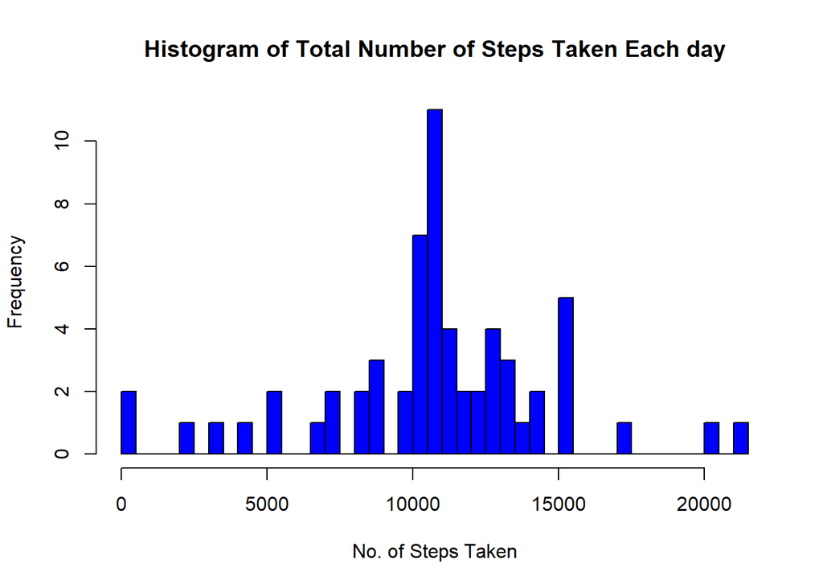

```r
sum_steps2<-aggregate(steps~date,r,sum)
mean_2<-mean(sum_steps2$steps)
Median_2<-median(sum_steps2$steps)
hist(sum_steps2$steps, col = "blue", xlab = "No. of Steps Taken", main = "Histogram of Total Number of Steps Taken Each day", breaks = 40)
```

The mean of the imputed dataset is **10766.19** and the median is **10766.19**. Imputing the data using the technique I have used has resulted in both the mean and median of the imputed data equalling the mean of the non-imputed data

## Are there differences in activity patterns between weekdays and weekends?

## Assignment Questions - Section 4

**Q1 Create a new factor variable in the dataset with two levels - “weekday” and “weekend” indicating whether a given date is a weekday or weekend day.**

I created a new copy of the imputed data called *imputeddata*. Then I created another column for days of the week and whwther its a weekend or not. The code is given below

```r
imputeddata<-r
imputeddata$days<-as.factor(weekdays(imputeddata$date))
imputeddata$days2<-as.factor(weekdays(imputeddata$date))
levels(imputeddata$days)[levels(imputeddata$days) == "Saturday"] <- "Weekend"
levels(imputeddata$days)[levels(imputeddata$days) == "Sunday"] <- "Weekend"
levels(imputeddata$days)[levels(imputeddata$days) == "Monday"] <- "Weekday"
levels(imputeddata$days)[levels(imputeddata$days) == "Tuesday"] <- "Weekday"
levels(imputeddata$days)[levels(imputeddata$days) == "Wednesday"] <- "Weekday"
levels(imputeddata$days)[levels(imputeddata$days) == "Thursday"] <- "Weekday"
levels(imputeddata$days)[levels(imputeddata$days) == "Friday"] <- "Weekday"
```

**Q2 Make a panel plot containing a time series plot (i.e. type=“l”) of the 5-minute interval (x-axis) and the average number of steps taken, averaged across all weekday days or weekend days (y-axis)**

Following is the code to create the plots for the weekday and weekend graphs for average number of steps taken in 5 minute intervals across all weekdays or weekends

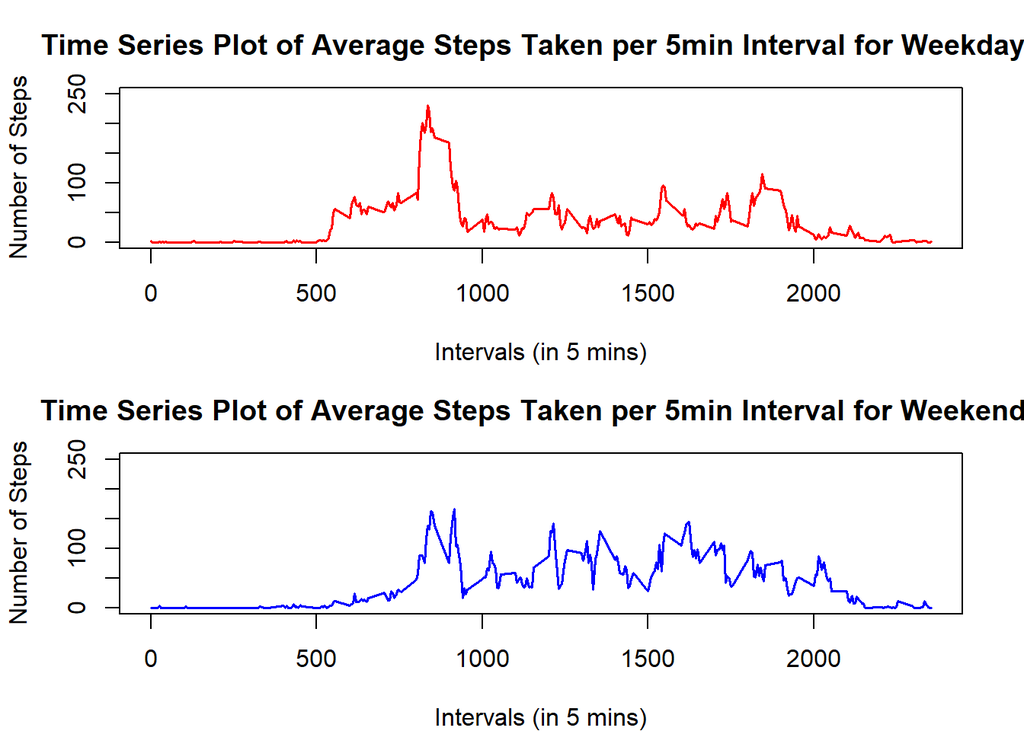

```r
weekday_data<-imputeddata[imputeddata$days=="Weekday",]
weekend_data<-imputeddata[imputeddata$days=="Weekend",]
mean_weekday<-aggregate(steps~interval,weekday_data,mean)
mean_weekend<-aggregate(steps~interval,weekend_data,mean)
par(mfrow=c(2, 1), mar=c(4, 4.1, 3, 2.1))
plot(mean_weekday$interval, mean_weekday$steps, type="l",
     main="Time Series Plot of Average Steps Taken per 5min Interval for Weekdays",
     xlab="Intervals (in 5 mins)", ylab="Number of Steps", col="red", lwd=1.5, ylim=c(0, 250))
plot(mean_weekend$interval, mean_weekend$steps, type="l",
     main="Time Series Plot of Average Steps Taken per 5min Interval for Weekends",
     xlab="Intervals (in 5 mins)", ylab="Number of Steps", col="blue", lwd=1.5, ylim=c(0, 250))
```

Based on the plots there seem to be differences bwtween the activity patters of weekdays and weekends with activity being highest at 8-9 AM on Weekdays but activity on weekends is regularly high thorughout the active day